# Hands-on Exercise 9 - Information Dashboard Design: R methods

Author

Andy Tai

Published

June 22, 2026

Modified

June 22, 2026

## 1 Overview

Learning Objectives for this chapter are:

- create bullet chart by using ggplot2,
- create sparklines by using ggplot2 ,
- build industry standard dashboard by using R Shiny.

## 2 Getting Started

**(a) Install libraries**

The following R packages will be used:

- [tidyverse](https://www.tidyverse.org/) provides a collection of functions for performing data science task such as importing, tidying, wrangling data and visualising data. It is not a single package but a collection of modern R packages including but not limited to [readr](https://readr.tidyverse.org/), [tidyr](https://tidyr.tidyverse.org/), [dplyr](https://dplyr.tidyverse.org/), [ggplot](https://ggplot2.tidyverse.org/), [tibble](https://tibble.tidyverse.org/), [stringr](https://stringr.tidyverse.org/), [forcats](https://forcats.tidyverse.org/) and [purrr](https://purrr.tidyverse.org/).
- [lubridate](https://r4va.netlify.app/chap31) provides functions to work with dates and times more efficiently.
- [ggthemes](https://r4va.netlify.app/chap31) is an extension of ggplot2. It provides additional [themes](https://yutannihilation.github.io/allYourFigureAreBelongToUs/ggthemes/) beyond the basic themes of ggplot2.
- [gtExtras](https://jthomasmock.github.io/gtExtras/) provides some additional helper functions to assist in creating beautiful tables with [gt](https://gt.rstudio.com/), an R package specially designed for anyone to make wonderful-looking tables using the R programming language.
- [reactable](https://glin.github.io/reactable/) provides functions to create interactive data tables for R, based on the [React Table](https://github.com/tanstack/table/tree/v7) library and made with reactR.
- [reactablefmtr](https://kcuilla.github.io/reactablefmtr/) provides various features to streamline and enhance the styling of interactive reactable tables with easy-to-use and highly-customizable functions and themes.
- svglite

Code chunk below will be used to check if these packages have been installed and also will load them into the working R environment.

```r
pacman::p_load(lubridate, ggthemes, reactable,
reactablefmtr, gt, gtExtras, tidyverse,svglite)
```

**(b) Import Data**

`odbcConnectAccess()` of [**RODBC**](https://cran.r-project.org/web/packages/RODBC/) package is used used to import a database query table into R.

If an issue arises, [change the R environment from 64bit to 32 bit](https://sites.google.com/site/rforfishandwildlifegrads/home/week-2-databases-types-formats-and-practical-considerations/changing-r-studio-to-default-32-bit-r):

From R Studio > Tools > Global Options > General > Basic > R session > R version: Change > Use your machine’s default version of R (32-bit).

Note: Since R 4.2.0, 32-bit builds are no longer provided.

```r
library(RODBC)
con <- odbcConnectAccess2007('data/Coffee Chain.mdb')
coffeechain <- sqlFetch(con, 'CoffeeChain Query')
write_rds(coffeechain, "data/CoffeeChain.rds")
odbcClose(con)
```

**(c) Wrangle Data**

The code chunk below is used to import CoffeeChain.rds into R.

```r
coffeechain <- read_rds("data/rds/CoffeeChain.rds")
```

**Note**

Note: If *coffeechain* is already available in R, above step is optional

The code chunk below is used to aggregate Sales and Budgeted Sales at the Product level.

```r
product <- coffeechain %>%
  group_by(`Product`) %>%
  summarise(`target` = sum(`Budget Sales`),
            `current` = sum(`Sales`)) %>%
  ungroup()
```

## 3 Bullet Chart and Sparklines in ggplot2

**(a) Bullet Chart**

The code chunk below is used to plot the bullet charts using ggplot2 functions.

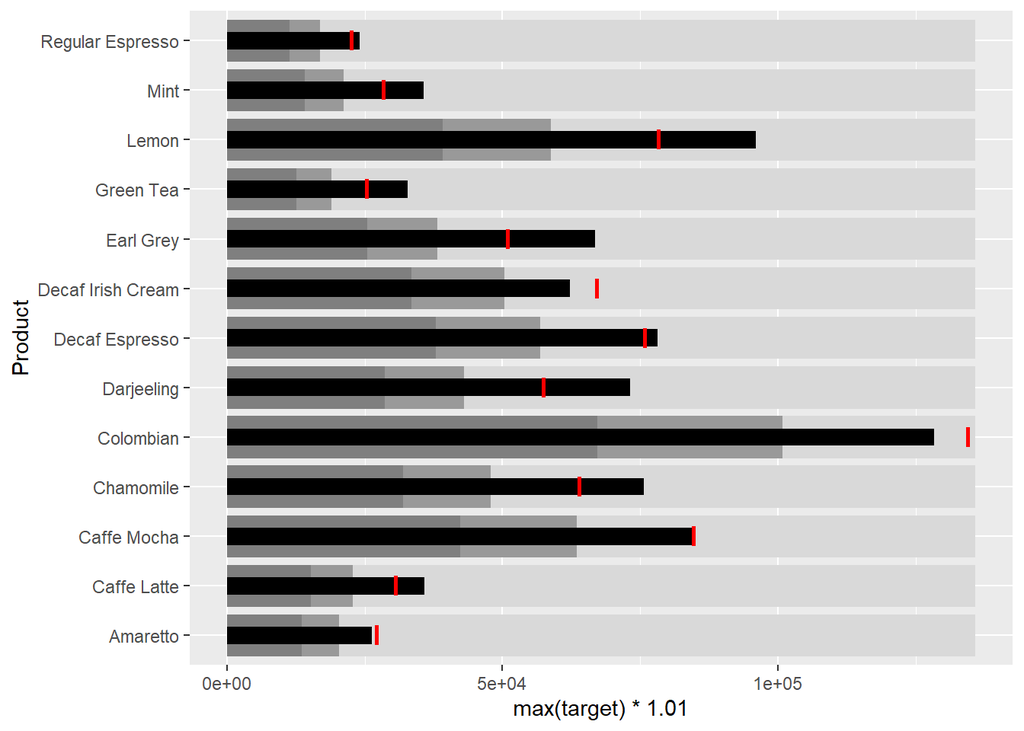

```r
ggplot(product, aes(Product, current)) +
  geom_col(aes(Product, max(target) * 1.01),
           fill="grey85", width=0.85) +
  geom_col(aes(Product, target * 0.75),
           fill="grey60", width=0.85) +
  geom_col(aes(Product, target * 0.5),
           fill="grey50", width=0.85) +
  geom_col(aes(Product, current),
           width=0.35,
           fill = "black") +
  geom_errorbar(aes(y = target,
                    x = Product,
                    ymin = target,
                    ymax= target),
                width = .4,
                colour = "red",
                size = 1) +
  coord_flip()
```

**(b) Sparklines**

We compute the minimum, maximum, end of month sales, as well as the 25 and 75 quantiles.

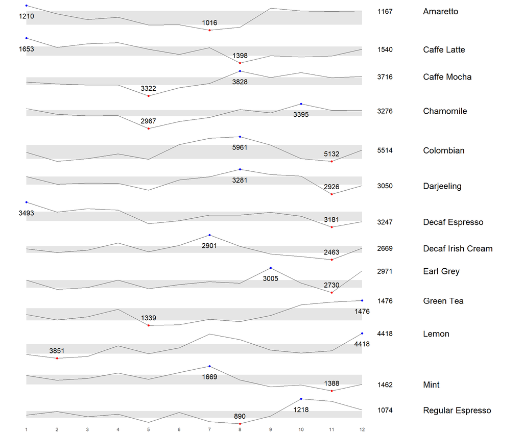

```r
sales_report <- coffeechain %>%
  filter(Date >= "2013-01-01") %>%
  mutate(Month = month(Date)) %>%
  group_by(Month, Product) %>%
  summarise(Sales = sum(Sales)) %>%
  ungroup() %>%
  select(Month, Product, Sales)

mins <- group_by(sales_report, Product) %>%
  slice(which.min(Sales))

maxs <- group_by(sales_report, Product) %>%
  slice(which.max(Sales))

ends <- group_by(sales_report, Product) %>%
  filter(Month == max(Month))

quarts <- sales_report %>%
  group_by(Product) %>%
  summarise(quart1 = quantile(Sales, 0.25),
            quart2 = quantile(Sales, 0.75)) %>%
  right_join(sales_report)

ggplot(sales_report, aes(x = Month, y = Sales)) +
  facet_grid(Product ~ ., scales = "free_y") +
  geom_ribbon(data = quarts, aes(ymin = quart1, max = quart2),
              fill = 'grey90') +
  geom_line(size = 0.3) +
  geom_point(data = mins, col = 'red') +
  geom_point(data = maxs, col = 'blue') +
  geom_text(data = mins, aes(label = Sales), vjust = -1, size = 4) +
  geom_text(data = maxs, aes(label = Sales), vjust = 2.5, size = 4) +
  geom_text(data = ends, aes(label = Sales), hjust = 0, nudge_x = 0.5, size = 4) +
  geom_text(data = ends, aes(label = Product), hjust = 0, nudge_x = 2.0, size = 5) +
  expand_limits(x = max(sales_report$Month) +
                  (0.4 * (max(sales_report$Month) - min(sales_report$Month)))) +
  scale_x_continuous(breaks = seq(1, 12, 1)) +
  scale_y_continuous(expand = c(0.1, 0)) +
  theme_tufte(base_size = 10, base_family = "sans") +
  theme(axis.title = element_blank(),
        axis.text.y = element_blank(),
        axis.ticks = element_blank(),
        strip.text = element_blank())
```

## 4 Static Information Dashboard: gt and gtExtras

Create static information dashboard by using [gt](https://gt.rstudio.com/) and [gtExtras](https://jthomasmock.github.io/gtExtras/) packages.

**(a) Bullet Chart**

```r
product %>%
  gt::gt() %>%
  gt_plt_bullet(column = current,
              target = target,
              width = 60,
              palette = c("lightblue",
                          "black")) %>%
  gt_theme_538()
```

| Product | current |
| --- | --- |
| Amaretto |  |
| Caffe Latte |  |
| Caffe Mocha |  |
| Chamomile |  |
| Colombian |  |
| Darjeeling |  |
| Decaf Espresso |  |
| Decaf Irish Cream |  |
| Earl Grey |  |
| Green Tea |  |
| Lemon |  |
| Mint |  |
| Regular Espresso |  |

**(b) Sparklines**

Note that there is a current bug in gtExtras 0.62 version making the background dark even when ‘white’ is specified. To work around this, I specified ‘white’ in the first color palette forcing the lines to be ‘white’ to contrast against the dark background

```r
theme_set(theme_minimal())

report <- coffeechain %>%
  mutate(Year = year(Date)) %>%
  filter(Year == "2013") %>%
  mutate(Month = month(Date,
                       label = TRUE,
                       abbr = TRUE)) %>%
  group_by(Product, Month) %>%
  summarise(Sales = sum(Sales)) %>%
  ungroup()

report %>%
  group_by(Product) %>%
  summarize('Monthly Sales' = list(Sales),
            .groups = "drop") %>%
  gt() %>%
  gt_plt_sparkline('Monthly Sales',
                   same_limit = FALSE,
                   palette = c("white", "white", "purple", "green", "white")) %>%
  tab_options(table.background.color = "white")
```

| Product | Monthly Sales |
| --- | --- |
| Amaretto |  |
| Caffe Latte |  |
| Caffe Mocha |  |
| Chamomile |  |
| Colombian |  |
| Darjeeling |  |
| Decaf Espresso |  |
| Decaf Irish Cream |  |
| Earl Grey |  |
| Green Tea |  |
| Lemon |  |
| Mint |  |
| Regular Espresso |  |

**(c) Statistics**

```r
report %>%
  group_by(Product) %>%
  summarise("Min" = min(Sales, na.rm = T),
            "Max" = max(Sales, na.rm = T),
            "Average" = mean(Sales, na.rm = T)
            ) %>%
  gt() %>%
  fmt_number(columns = 4,
    decimals = 2)
```

| Product | Min | Max | Average |
| --- | --- | --- | --- |
| Amaretto | 1016 | 1210 | 1,119.00 |
| Caffe Latte | 1398 | 1653 | 1,528.33 |
| Caffe Mocha | 3322 | 3828 | 3,613.92 |
| Chamomile | 2967 | 3395 | 3,217.42 |
| Colombian | 5132 | 5961 | 5,457.25 |
| Darjeeling | 2926 | 3281 | 3,112.67 |
| Decaf Espresso | 3181 | 3493 | 3,326.83 |
| Decaf Irish Cream | 2463 | 2901 | 2,648.25 |
| Earl Grey | 2730 | 3005 | 2,841.83 |
| Green Tea | 1339 | 1476 | 1,398.75 |
| Lemon | 3851 | 4418 | 4,080.83 |
| Mint | 1388 | 1669 | 1,519.17 |
| Regular Espresso | 890 | 1218 | 1,023.42 |

**(d) table+sparklines**

```r
spark <- report %>%
  group_by(Product) %>%
  summarize('Monthly Sales' = list(Sales),
            .groups = "drop")

sales <- report %>%
  group_by(Product) %>%
  summarise("Min" = min(Sales, na.rm = T),
            "Max" = max(Sales, na.rm = T),
            "Average" = mean(Sales, na.rm = T))

sales_data <- left_join(sales, spark)

sales_data %>%
  gt() %>%
  gt_plt_sparkline('Monthly Sales',
                   same_limit = FALSE,
                   palette = c("white", "white", "purple", "green", "white")) %>%
  tab_options(table.background.color = "white")
```

| Product | Min | Max | Average | Monthly Sales |
| --- | --- | --- | --- | --- |
| Amaretto | 1016 | 1210 | 1119.000 |  |
| Caffe Latte | 1398 | 1653 | 1528.333 |  |
| Caffe Mocha | 3322 | 3828 | 3613.917 |  |
| Chamomile | 2967 | 3395 | 3217.417 |  |
| Colombian | 5132 | 5961 | 5457.250 |  |
| Darjeeling | 2926 | 3281 | 3112.667 |  |
| Decaf Espresso | 3181 | 3493 | 3326.833 |  |
| Decaf Irish Cream | 2463 | 2901 | 2648.250 |  |
| Earl Grey | 2730 | 3005 | 2841.833 |  |
| Green Tea | 1339 | 1476 | 1398.750 |  |
| Lemon | 3851 | 4418 | 4080.833 |  |
| Mint | 1388 | 1669 | 1519.167 |  |
| Regular Espresso | 890 | 1218 | 1023.417 |  |

**(e) table+sparklines+bullet**

```r
bullet <- coffeechain %>%
  filter(Date >= "2013-01-01") %>%
  group_by(Product) %>%
  summarise(Target = sum(`Budget Sales`),
            Actual = sum(Sales)) %>%
  ungroup()

sales_data <- sales_data %>%
  left_join(bullet)

sales_data %>%
  gt() %>%
  gt_plt_sparkline('Monthly Sales',
                   same_limit = FALSE,
                   palette = c("white", "white", "purple", "green", "white")) %>%
  gt_plt_bullet(column = Actual,
                target = Target,
                width = 28,
                palette = c("lightblue", "black")) %>%
  gt_theme_538()
```

| Product | Min | Max | Average | Monthly Sales | Actual |
| --- | --- | --- | --- | --- | --- |
| Amaretto | 1016 | 1210 | 1119.000 |  |  |
| Caffe Latte | 1398 | 1653 | 1528.333 |  |  |
| Caffe Mocha | 3322 | 3828 | 3613.917 |  |  |
| Chamomile | 2967 | 3395 | 3217.417 |  |  |
| Colombian | 5132 | 5961 | 5457.250 |  |  |
| Darjeeling | 2926 | 3281 | 3112.667 |  |  |
| Decaf Espresso | 3181 | 3493 | 3326.833 |  |  |
| Decaf Irish Cream | 2463 | 2901 | 2648.250 |  |  |
| Earl Grey | 2730 | 3005 | 2841.833 |  |  |
| Green Tea | 1339 | 1476 | 1398.750 |  |  |
| Lemon | 3851 | 4418 | 4080.833 |  |  |
| Mint | 1388 | 1669 | 1519.167 |  |  |
| Regular Espresso | 890 | 1218 | 1023.417 |  |  |

## 5 Interactive Information Dashboard: reactable and reactablefmtr

Create interactive information dashboard by using [reactable](https://glin.github.io/reactable/) and [reactablefmtr](https://kcuilla.github.io/reactablefmtr/) packages.

In order to build an interactive sparklines, dataui R package needs to be installed.

```r
remotes::install_github("timelyportfolio/dataui", force = TRUE)
remotes::install_github("kcuilla/reactablefmtr")
```

Load the packages onto R environment

```r
library(dataui)
library(reactablefmtr)
```

**(a) sparklines**

Prepare the list field

```r
report <- report %>%
  group_by(Product) %>%
  summarize(`Monthly Sales` = list(Sales))
```

Next, [react_sparkline](https://kcuilla.github.io/reactablefmtr/reference/react_sparkline.html) will be used to plot the sparklines

```r
reactable(
  report,
  columns = list(
    Product = colDef(maxWidth = 200),
    `Monthly Sales` = colDef(
      cell = react_sparkline(report)
    )
  )
)
```

| Product | Monthly Sales |
| --- | --- |
| Amaretto | [1210, 1144, 1100, 1117, 1057, 1059, 1016, 1039, 1188, 1167, 1164, 1167] |
| Caffe Latte | [1653, 1559, 1597, 1608, 1539, 1487, 1556, 1398, 1473, 1460, 1470, 1540] |
| Caffe Mocha | [3604, 3566, 3544, 3541, 3322, 3488, 3573, 3828, 3697, 3796, 3692, 3716] |
| Chamomile | [3313, 3213, 3188, 3193, 2967, 3089, 3160, 3295, 3238, 3395, 3282, 3276] |
| Colombian | [5439, 5135, 5225, 5381, 5203, 5696, 5904, 5961, 5675, 5222, 5132, 5514] |
| Darjeeling | [3178, 3067, 3084, 3082, 2985, 3130, 3176, 3281, 3208, 3185, 2926, 3050] |
| Decaf Espresso | [3493, 3368, 3412, 3394, 3222, 3260, 3331, 3332, 3366, 3316, 3181, 3247] |
| Decaf Irish Cream | [2656, 2593, 2633, 2759, 2605, 2715, 2901, 2702, 2563, 2520, 2463, 2669] |
| Earl Grey | [2867, 2765, 2785, 2868, 2774, 2818, 2851, 2833, 3005, 2835, 2730, 2971] |
| Green Tea | [1399, 1369, 1386, 1428, 1339, 1342, 1373, 1360, 1394, 1452, 1467, 1476] |

[output cut: 3 more lines]

**(b) change pagesize**

By default the pagesize is 10. Argument defaultPageSize is used to change the default setting.

```r
reactable(
  report,
  defaultPageSize = 13,
  columns = list(
    Product = colDef(maxWidth = 200),
    `Monthly Sales` = colDef(
      cell = react_sparkline(report)
    )
  )
)
```

| Product | Monthly Sales |
| --- | --- |
| Amaretto | [1210, 1144, 1100, 1117, 1057, 1059, 1016, 1039, 1188, 1167, 1164, 1167] |
| Caffe Latte | [1653, 1559, 1597, 1608, 1539, 1487, 1556, 1398, 1473, 1460, 1470, 1540] |
| Caffe Mocha | [3604, 3566, 3544, 3541, 3322, 3488, 3573, 3828, 3697, 3796, 3692, 3716] |
| Chamomile | [3313, 3213, 3188, 3193, 2967, 3089, 3160, 3295, 3238, 3395, 3282, 3276] |
| Colombian | [5439, 5135, 5225, 5381, 5203, 5696, 5904, 5961, 5675, 5222, 5132, 5514] |
| Darjeeling | [3178, 3067, 3084, 3082, 2985, 3130, 3176, 3281, 3208, 3185, 2926, 3050] |
| Decaf Espresso | [3493, 3368, 3412, 3394, 3222, 3260, 3331, 3332, 3366, 3316, 3181, 3247] |
| Decaf Irish Cream | [2656, 2593, 2633, 2759, 2605, 2715, 2901, 2702, 2563, 2520, 2463, 2669] |
| Earl Grey | [2867, 2765, 2785, 2868, 2774, 2818, 2851, 2833, 3005, 2835, 2730, 2971] |
| Green Tea | [1399, 1369, 1386, 1428, 1339, 1342, 1373, 1360, 1394, 1452, 1467, 1476] |

[output cut: 3 more lines]

**(c) points/labels**

`highlight_points` argument is used to show the minimum and maximum values points and `label` argument is used to label first and last values.

```r
reactable(
  report,
  defaultPageSize = 13,
  columns = list(
    Product = colDef(maxWidth = 200),
    `Monthly Sales` = colDef(
      cell = react_sparkline(
        report,
        highlight_points = highlight_points(
          min = "red", max = "blue"),
        labels = c("first", "last")
        )
    )
  )
)
```

| Product | Monthly Sales |
| --- | --- |
| Amaretto | [1210, 1144, 1100, 1117, 1057, 1059, 1016, 1039, 1188, 1167, 1164, 1167] |
| Caffe Latte | [1653, 1559, 1597, 1608, 1539, 1487, 1556, 1398, 1473, 1460, 1470, 1540] |
| Caffe Mocha | [3604, 3566, 3544, 3541, 3322, 3488, 3573, 3828, 3697, 3796, 3692, 3716] |
| Chamomile | [3313, 3213, 3188, 3193, 2967, 3089, 3160, 3295, 3238, 3395, 3282, 3276] |
| Colombian | [5439, 5135, 5225, 5381, 5203, 5696, 5904, 5961, 5675, 5222, 5132, 5514] |
| Darjeeling | [3178, 3067, 3084, 3082, 2985, 3130, 3176, 3281, 3208, 3185, 2926, 3050] |
| Decaf Espresso | [3493, 3368, 3412, 3394, 3222, 3260, 3331, 3332, 3366, 3316, 3181, 3247] |
| Decaf Irish Cream | [2656, 2593, 2633, 2759, 2605, 2715, 2901, 2702, 2563, 2520, 2463, 2669] |
| Earl Grey | [2867, 2765, 2785, 2868, 2774, 2818, 2851, 2833, 3005, 2835, 2730, 2971] |
| Green Tea | [1399, 1369, 1386, 1428, 1339, 1342, 1373, 1360, 1394, 1452, 1467, 1476] |

[output cut: 3 more lines]

**(d) reference line**

`statline` argument is used to show the mean line.

```r
reactable(
  report,
  defaultPageSize = 13,
  columns = list(
    Product = colDef(maxWidth = 200),
    `Monthly Sales` = colDef(
      cell = react_sparkline(
        report,
        highlight_points = highlight_points(
          min = "red", max = "blue"),
        statline = "mean"
        )
    )
  )
)
```

| Product | Monthly Sales |
| --- | --- |
| Amaretto | [1210, 1144, 1100, 1117, 1057, 1059, 1016, 1039, 1188, 1167, 1164, 1167] |
| Caffe Latte | [1653, 1559, 1597, 1608, 1539, 1487, 1556, 1398, 1473, 1460, 1470, 1540] |
| Caffe Mocha | [3604, 3566, 3544, 3541, 3322, 3488, 3573, 3828, 3697, 3796, 3692, 3716] |
| Chamomile | [3313, 3213, 3188, 3193, 2967, 3089, 3160, 3295, 3238, 3395, 3282, 3276] |
| Colombian | [5439, 5135, 5225, 5381, 5203, 5696, 5904, 5961, 5675, 5222, 5132, 5514] |
| Darjeeling | [3178, 3067, 3084, 3082, 2985, 3130, 3176, 3281, 3208, 3185, 2926, 3050] |
| Decaf Espresso | [3493, 3368, 3412, 3394, 3222, 3260, 3331, 3332, 3366, 3316, 3181, 3247] |
| Decaf Irish Cream | [2656, 2593, 2633, 2759, 2605, 2715, 2901, 2702, 2563, 2520, 2463, 2669] |
| Earl Grey | [2867, 2765, 2785, 2868, 2774, 2818, 2851, 2833, 3005, 2835, 2730, 2971] |
| Green Tea | [1399, 1369, 1386, 1428, 1339, 1342, 1373, 1360, 1394, 1452, 1467, 1476] |

[output cut: 3 more lines]

**(e) bandline**

bandline can be added by using the `bandline` argument.

```r
reactable(
  report,
  defaultPageSize = 13,
  columns = list(
    Product = colDef(maxWidth = 200),
    `Monthly Sales` = colDef(
      cell = react_sparkline(
        report,
        highlight_points = highlight_points(
          min = "red", max = "blue"),
        line_width = 1,
        bandline = "innerquartiles",
        bandline_color = "green"
        )
    )
  )
)
```

| Product | Monthly Sales |
| --- | --- |
| Amaretto | [1210, 1144, 1100, 1117, 1057, 1059, 1016, 1039, 1188, 1167, 1164, 1167] |
| Caffe Latte | [1653, 1559, 1597, 1608, 1539, 1487, 1556, 1398, 1473, 1460, 1470, 1540] |
| Caffe Mocha | [3604, 3566, 3544, 3541, 3322, 3488, 3573, 3828, 3697, 3796, 3692, 3716] |
| Chamomile | [3313, 3213, 3188, 3193, 2967, 3089, 3160, 3295, 3238, 3395, 3282, 3276] |
| Colombian | [5439, 5135, 5225, 5381, 5203, 5696, 5904, 5961, 5675, 5222, 5132, 5514] |
| Darjeeling | [3178, 3067, 3084, 3082, 2985, 3130, 3176, 3281, 3208, 3185, 2926, 3050] |
| Decaf Espresso | [3493, 3368, 3412, 3394, 3222, 3260, 3331, 3332, 3366, 3316, 3181, 3247] |
| Decaf Irish Cream | [2656, 2593, 2633, 2759, 2605, 2715, 2901, 2702, 2563, 2520, 2463, 2669] |
| Earl Grey | [2867, 2765, 2785, 2868, 2774, 2818, 2851, 2833, 3005, 2835, 2730, 2971] |
| Green Tea | [1399, 1369, 1386, 1428, 1339, 1342, 1373, 1360, 1394, 1452, 1467, 1476] |

[output cut: 3 more lines]

**(f) sparkbar**

Instead of displaying the values as sparklines, we can display them as sparkbars.

```r
reactable(
  report,
  defaultPageSize = 13,
  columns = list(
    Product = colDef(maxWidth = 200),
    `Monthly Sales` = colDef(
      cell = react_sparkbar(
        report,
        highlight_bars = highlight_bars(
          min = "red", max = "blue"),
        bandline = "innerquartiles",
        statline = "mean")
    )
  )
)
```

| Product | Monthly Sales |
| --- | --- |
| Amaretto | [1210, 1144, 1100, 1117, 1057, 1059, 1016, 1039, 1188, 1167, 1164, 1167] |
| Caffe Latte | [1653, 1559, 1597, 1608, 1539, 1487, 1556, 1398, 1473, 1460, 1470, 1540] |
| Caffe Mocha | [3604, 3566, 3544, 3541, 3322, 3488, 3573, 3828, 3697, 3796, 3692, 3716] |
| Chamomile | [3313, 3213, 3188, 3193, 2967, 3089, 3160, 3295, 3238, 3395, 3282, 3276] |
| Colombian | [5439, 5135, 5225, 5381, 5203, 5696, 5904, 5961, 5675, 5222, 5132, 5514] |
| Darjeeling | [3178, 3067, 3084, 3082, 2985, 3130, 3176, 3281, 3208, 3185, 2926, 3050] |
| Decaf Espresso | [3493, 3368, 3412, 3394, 3222, 3260, 3331, 3332, 3366, 3316, 3181, 3247] |
| Decaf Irish Cream | [2656, 2593, 2633, 2759, 2605, 2715, 2901, 2702, 2563, 2520, 2463, 2669] |
| Earl Grey | [2867, 2765, 2785, 2868, 2774, 2818, 2851, 2833, 3005, 2835, 2730, 2971] |
| Green Tea | [1399, 1369, 1386, 1428, 1339, 1342, 1373, 1360, 1394, 1452, 1467, 1476] |

[output cut: 3 more lines]